# Real-time modeling and projections of the COVID-19 epidemic in Switzerland

Christian L. Althaus, Institute of Social and Preventive Medicine, University of Bern, Switzerland

24 April 2020

#### Important note: This report is work in progress and has not been peer-review. The short-term projections need to be interpreted with caution (also see Notes).

### Introduction

Switzerland reported its first case of coronavirus disease 2019 (COVID-19) on 25 Feb 2020. As of 22 Apr 2020, there have been 28152 confirmed cases and 1537 reported deaths ([source](https://github.com/daenuprobst/covid19-cases-switzerland)). Interpreting trends in the daily numbers of reported cases can be challenging as a significant proportion of particularly mild or asymptomatic cases cannot be diagnosed and will go unreported (see [here](https://cmmid.github.io/topics/covid19/severity/global_cfr_estimates.html) for estimates of under-reporting). Here, we aim to describe the COVID-19 epidemic in Switzerland by tracking the numbers of reported deaths. To this end, we fit a dynamic transmission model to the daily number of reported deaths, estimate the reduction in transmission after the strengthening of social distancing measures on 17 Mar 2020, and project the further course of the COVID-19 epidemic in Switzerland.

### Methods

We consider a SEIR transmission model with additional compartments for hospitalization and critical care (ICU) (see R Markdown file and Table). We use a maximum likelihood framework to fit the model to the reported numbers of deaths, assuming the daily numbers of deaths are Poisson distributed (see [Althaus et al.](http://dx.doi.org/10.1016/j.epidem.2015.03.001) for further details on the methods). We assume constant uncontrolled transmission until the strengthening of social distancing measures on 17 Mar 2020 and then estimate the following reduction in transmission.

**Table. Parameters of the COVID-19 transmission model.**

| Parameter | Value | Source |
| --- | --- | --- |
| Population size of Switzerland | 8.6 million | [Federal Statistical Office](https://www.bfs.admin.ch/bfs/en/home/statistics/population.html) |
| Serial interval | 5.2 days | [Ganyani et al.](https://www.medrxiv.org/content/10.1101/2020.03.05.20031815v1) |
| Duration from onset of symptoms to hospitalization | 5 days | [Ferguson et al.](https://www.imperial.ac.uk/media/imperial-college/medicine/sph/ide/gida-fellowships/Imperial-College-COVID19-NPI-modelling-16-03-2020.pdf) |
| Duration of hospitalization | 16 days | [Ferguson et al.](https://www.imperial.ac.uk/media/imperial-college/medicine/sph/ide/gida-fellowships/Imperial-College-COVID19-NPI-modelling-16-03-2020.pdf) |
| Duration in critical care (ICU) | 10 days | [Ferguson et al.](https://www.imperial.ac.uk/media/imperial-college/medicine/sph/ide/gida-fellowships/Imperial-College-COVID19-NPI-modelling-16-03-2020.pdf) |
| Proportion hospitalized that require critical care | 30% | [Ferguson et al.](https://www.imperial.ac.uk/media/imperial-college/medicine/sph/ide/gida-fellowships/Imperial-College-COVID19-NPI-modelling-16-03-2020.pdf) |
| Proportion in critical care that will die | 50% | [Ferguson et al.](https://www.imperial.ac.uk/media/imperial-college/medicine/sph/ide/gida-fellowships/Imperial-College-COVID19-NPI-modelling-16-03-2020.pdf) |
| Overall case fatality ratio | 1.4% | Verity et al. and [Wu et al.](https://doi.org/10.1038/s41591-020-0822-7) |
| Basic reproduction number $R_0$ | 2.78 (95% CI: 2.51 - 3.11) | Estimated |
| Reduction in transmission after 17 March 2020 | 89% (95% CI: 83%-94%) | Estimated |

### Results

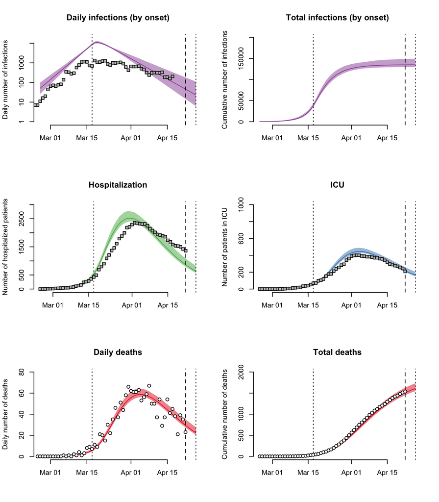

**Figure. Projected numbers of infections, hospitalizations, patients in ICU and deaths for the COVID-19 epidemic in Switzerland.** The model was fitted to daily numbers of reported deaths (white circles). Data of confirmed cases are shifted by 5 days to account for the reporting delay. Data about hospitalizations and patients in ICU are shown for validation (gray squares). Vertical dotted and dashed lines indicate the time points of the strengthening and planned relaxation of social distancing measures (17 Mar 2020 and 26 Apr 2020, respectively) and the last data point (22 Apr 2020). Note the logarithmic vertical axis for the number of daily infections.

### Notes

- 24 Apr 2020: Assuming a constant effective reprodution number $R_e$ since the strengthening of social distancing measures, the model projects a more optimistic reduction in new infections and hospitalizations than suggested by the data. This could indicate that $R_e$ slightly increased since 17 March 2020 (also see changes in [Mobility Trends Reports](https://www.apple.com/covid19/mobility) by [Apple Inc.](https://www.apple.com)).
- 14 Apr 2020: Updated model structure and parameters.
- 9 Apr 2020: Updated model structure and parameters. Data allows to estimate the reduction in transmission after the strengthening of social distancing measures.
- 24 Mar 2020: Shortening the generation time from 7.5 days ([Li et al.](https://doi.org/10.1056/NEJMoa2001316)) to 5.2 days ([Ganyani et al.](https://www.medrxiv.org/content/10.1101/2020.03.05.20031815v1)) results in a lower estimate of $R_0$, and consequently more optimistic projections about epidemic control.

### Funding

This project receives funding from the European Union’s Horizon 2020 research and innovation programme - project EpiPose (No 101003688).